# STAT 253 - Final Project

Lucy Tran, Emydius Montes, Hengrui Jia

2022-12-08

## Data context

“Music Dataset: 1950 to 2019,” collected in a research study in 2020 using Spotify’s Python package and other web APIs, is a dataset consisting of basic information and metadata for 28,372 lyrical tracks released from 1950 to 2019. Each row in the dataset represents a track with its name, artist, release year, genre, lyrics, main topic, and normalized metadata. Here, metadata refers to musical features of a track, such as: danceability, loudness, acousticness, instrumentalness, valence, and energy. Besides, the authors include normalized data for each of the sixteen topics a track can demonstrate, which ultimately determines its main topic. Examples of such topics are: night/time, violence, sadness, romantic, etc.

```r
# Library statements
library(dplyr);
library(readr);
library(broom);
library(ggplot2);
library(tidymodels);

tidymodels_prefer();

# Read in data
music <- read_csv("tcc_ceds_music.csv")

head(music)
```

```
## # A tibble: 6 × 31
##    ...1 artist_name   track…¹ relea…² genre lyrics   len  dating viole…³ world…⁴
##   <dbl> <chr>         <chr>     <dbl> <chr> <chr>  <dbl>   <dbl>   <dbl>   <dbl>
## 1     0 mukesh        mohabb…    1950 pop   hold …    95 5.98e-4 0.0637  5.98e-4
## 2     4 frankie laine i beli…    1950 pop   belie…    51 3.55e-2 0.0968  4.43e-1
## 3     6 johnnie ray   cry        1950 pop   sweet…    24 2.77e-3 0.00277 2.77e-3
## 4    10 pérez prado   patric…    1950 pop   kiss …    54 4.82e-2 0.00155 1.55e-3
## 5    12 giorgos papa… apopse…    1950 pop   till …    48 1.35e-3 0.00135 4.18e-1
## 6    14 perry como    round …    1950 pop   convo…    98 1.05e-3 0.421   1.05e-3
## # … with 21 more variables: `night/time` <dbl>, `shake the audience` <dbl>,
## #   `family/gospel` <dbl>, romantic <dbl>, communication <dbl>, obscene <dbl>,
## #   music <dbl>, `movement/places` <dbl>, `light/visual perceptions` <dbl>,
## #   `family/spiritual` <dbl>, `like/girls` <dbl>, sadness <dbl>,
## #   feelings <dbl>, danceability <dbl>, loudness <dbl>, acousticness <dbl>,
## #   instrumentalness <dbl>, valence <dbl>, energy <dbl>, topic <chr>,
## #   age <dbl>, and abbreviated variable names ¹track_name, ²release_date, …
```

## Research questions

The dataset prompts three questions for further research:

1. It would be interesting to find out about general trends in music across decades. Are there any connections between a song’s release year and its musical features?
2. The dataset contains some of the most popular music genres: blues, country, hiphop, jazz, pop, reggae, and rock. Songs of these genres can be easily identified by ear, although what makes them distinctive from each other is often unexplained. Can we identify a song’s genre based on its musical features? Which musical feature(s) contribute the most to a song’s genre? Such answers could help us understand how the music industry, or more fundamentally, our human brain, classifies songs.
3. The dataset contains a column called “topic”. Although a track can have characteristics of multiple topics, this topic column tells us its main theme. In this project, we are interested in tracks whose topic is “violence”. If we are to group the tracks into 7 clusters (so hopefully they will correspond to the 7 genres) based on the musical features that are most useful in identifying a song’s genre (from questions #2), can these clusters tell us anything about their topics? If yes, which genre(s) does the cluster(s) whose major topic is “violence” mostly belong to? The answer to this question can suggest the genre that is the most violent in our dataset.

## Regression

### Data exploration

```r
# Clean data
music_clean_1 <- select(music, release_date, danceability, loudness, acousticness, instrumentalness, valence, energy)

head(music_clean_1)
```

```
## # A tibble: 6 × 7
##   release_date danceability loudness acousticness instrumentaln…¹ valence energy
##          <dbl>        <dbl>    <dbl>        <dbl>           <dbl>   <dbl>  <dbl>
## 1         1950        0.358    0.454       0.998       0.902        0.339  0.137
## 2         1950        0.332    0.648       0.955       0.00000153   0.325  0.263
## 3         1950        0.456    0.585       0.840       0            0.352  0.139
## 4         1950        0.687    0.744       0.0839      0.199        0.775  0.744
## 5         1950        0.292    0.646       0.976       0.000246     0.597  0.394
## 6         1950        0.689    0.686       0.899       0            0.768  0.550
## # … with abbreviated variable name ¹instrumentalness
```

```r
set.seed(253)

# Creation of CV folds
music_cv <- vfold_cv(data = music_clean_1, v = 10)
```

### Methods

```r
# Model specs
lm_spec <-
    linear_reg() %>%
    set_engine(engine = 'lm') %>%
    set_mode('regression')

lm_lasso_spec_tune <-
  linear_reg() %>%
  set_args(mixture = 1, penalty = tune()) %>% ## mixture = 1 indicates Lasso
  set_engine(engine = 'glmnet') %>% #note we are using a different engine
  set_mode('regression')
# Recipes & workflows
data_rec <- recipe(release_date ~ danceability + loudness + acousticness + instrumentalness + valence + energy, data = music_clean_1) %>%
    step_nzv(all_predictors()) %>% # removes variables with the same value
    step_corr()

ols_wf <- workflow() %>%
  add_recipe(data_rec) %>%
  add_model(lm_spec)

lasso_wf_tune <-  workflow() %>%
  add_recipe(data_rec) %>%
  add_model(lm_lasso_spec_tune)
# Fit & tune models
## Fit OLS model
ols_mod <- ols_wf %>%
  fit(data = music_clean_1)

## Fit & tune LASSO model
lasso_mod <- lasso_wf_tune %>%
  fit(data = music_clean_1)

penalty_grid <- grid_regular(
  penalty(range = c(-3, 1)), #log10 transformed
  levels = 30)

tune_output <- tune_grid( # new function for tuning parameters
  lasso_wf_tune, # workflow
  resamples = music_cv, # cv folds
  metrics = metric_set(rmse, rsq, mae),
  grid = penalty_grid # penalty grid defined above
)
```

```r
# GAM model spec
gam_spec <-
  gen_additive_mod() %>%
  set_engine(engine = 'mgcv') %>%
  set_mode('regression')

# GAM model
gam_mod <- fit(gam_spec,
               release_date ~ s(danceability) + s(loudness) + s(acousticness) + s(instrumentalness) + s(valence) + s(energy),
               data = music_clean_1)

gam_mod %>% pluck('fit') %>% summary()
```

```
##
## Family: gaussian
## Link function: identity
##
## Formula:
## release_date ~ s(danceability) + s(loudness) + s(acousticness) +
##     s(instrumentalness) + s(valence) + s(energy)
##
## Parametric coefficients:
##             Estimate Std. Error t value Pr(>|t|)
## (Intercept) 1.99e+03   8.48e-02   23469   <2e-16 ***
## ---
## Signif. codes:  0 '***' 0.001 '**' 0.01 '*' 0.05 '.' 0.1 ' ' 1
##
## Approximate significance of smooth terms:
##                       edf Ref.df      F p-value
## s(danceability)     4.789  5.848 410.81  <2e-16 ***
## s(loudness)         7.852  8.672 405.47  <2e-16 ***
## s(acousticness)     7.708  8.562 136.37  <2e-16 ***
## s(instrumentalness) 6.766  7.864  17.52  <2e-16 ***
## s(valence)          5.190  6.289 465.18  <2e-16 ***
## s(energy)           7.687  8.494  34.41  <2e-16 ***
## ---
## Signif. codes:  0 '***' 0.001 '**' 0.01 '*' 0.05 '.' 0.1 ' ' 1
##
## R-sq.(adj) =  0.403   Deviance explained = 40.4%
## GCV = 204.33  Scale est. = 204.04    n = 28372
```

## Data Exploration

First, let’s explore our data in order to shape our model choice.

```r
# Library statements
library(dplyr);
library(readr);
library(broom);
library(ggplot2);
library(tidymodels);
library(vip);
library(kknn)
tidymodels_prefer();

# Read in data
music <- read_csv("tcc_ceds_music.csv")
# Clean data
music_clean <- select(music, genre, danceability, loudness, acousticness, instrumentalness, valence, energy) %>%
  mutate(genre = factor(genre))

head(music_clean)
```

```
## # A tibble: 6 × 7
##   genre danceability loudness acousticness instrumentalness valence energy
##   <fct>        <dbl>    <dbl>        <dbl>            <dbl>   <dbl>  <dbl>
## 1 pop          0.358    0.454       0.998        0.902        0.339  0.137
## 2 pop          0.332    0.648       0.955        0.00000153   0.325  0.263
## 3 pop          0.456    0.585       0.840        0            0.352  0.139
## 4 pop          0.687    0.744       0.0839       0.199        0.775  0.744
## 5 pop          0.292    0.646       0.976        0.000246     0.597  0.394
## 6 pop          0.689    0.686       0.899        0            0.768  0.550
```

```r
set.seed(253)
```

```r
genre_count <- music_clean %>% group_by(genre) %>%
  summarise(n = n()) %>% mutate(freq=n/sum(n)) %>% arrange(-freq)
genre_count
```

```
## # A tibble: 7 × 3
##   genre       n   freq
##   <fct>   <int>  <dbl>
## 1 pop      7042 0.248
## 2 country  5445 0.192
## 3 blues    4604 0.162
## 4 rock     4034 0.142
## 5 jazz     3845 0.136
## 6 reggae   2498 0.0880
## 7 hip hop   904 0.0319
```

There are 7 genres in our dataset: blues, country, hip hop, jazz, pop, reggae, and rock. Pop has the largest frequency among all 7 genres at 24.8%; hip hop has the lowest frequency at 3.1%, and reggae has the second lowest frequency at 8.8%.

Because our outcome variable has 7 possible values, we cannot use logistic regression, which is used for binary classification. Hence, we will be answering our research question using random forest and K-nearest neighbors.

However, we note that since all our predictors - danceability, loudness, acousticness, instrumentalness, valence, and energy, are all numerical, it will be highly computationally intensive to perform random forest because there are so many possible splits to consider. And although KNN generally has low computational time because of its lazy learning approach, when paired with cross-validation and tune for the best K, it can be computationally heavy as well.

## Methods

### Random Forest

#### Fitting Models

For our models specification, we’ll start with the random forests of 1000 trees, and our trees will be complex with `min_n` of 2 (so all the leaf nodes will have at most 2 cases). To make our trees diverse and avoid overfitting (when all trees are too similar), each tree will have different predictors to consider at each split. This number of predictors also identifies the different forests we will test out to determine which `mtry` is best for our overall accuracy. Since we only have 6 predictors, we will test out every possible `mtry` and see which one has the best overall accuracy.

```r
# Model Specification
rf_spec <- rand_forest() %>%
  set_engine(engine = 'ranger') %>%
  set_args(mtry = NULL, # size of random subset of variables; default is floor(sqrt(number of total predictors))
           trees = 1000, # Number of trees
           min_n = 2,
           probability = FALSE, # FALSE: get hard predictions (not needed for regression)
           importance = 'impurity') %>% # we'll come back to this at the end
  set_mode('classification')

# Recipe
data_rec <- recipe(genre ~ danceability+acousticness+loudness+instrumentalness+valence+energy, data = music_clean)

# Workflows
## Create workflows for mtry = 1, 2, 3, 4, 5, and 6
data_wf_mtry1 <- workflow() %>%
  add_model(rf_spec %>% set_args(mtry = 1)) %>%
  add_recipe(data_rec)

data_wf_mtry2 <- workflow() %>%
  add_model(rf_spec %>% set_args(mtry = 2)) %>%
  add_recipe(data_rec)

data_wf_mtry3 <- workflow() %>%
  add_model(rf_spec %>% set_args(mtry = 3)) %>%
  add_recipe(data_rec)

data_wf_mtry4 <- workflow() %>%
  add_model(rf_spec %>% set_args(mtry = 4)) %>%
  add_recipe(data_rec)

data_wf_mtry5 <- workflow() %>%
  add_model(rf_spec %>% set_args(mtry = 5)) %>%
  add_recipe(data_rec)

data_wf_mtry6 <- workflow() %>%
  add_model(rf_spec %>% set_args(mtry = 6)) %>%
  add_recipe(data_rec)
```

```r
# Fit Models
# Fit models for mtry = 2, 3, 4, 5, and 6
set.seed(253) # make sure to run this before each fit so that you have the same 1000 trees
data_fit_mtry1 <- fit(data_wf_mtry1, data = music_clean)

set.seed(253)
data_fit_mtry2 <- fit(data_wf_mtry2, data = music_clean)

set.seed(253)
data_fit_mtry3 <- fit(data_wf_mtry3, data = music_clean)

set.seed(253)
data_fit_mtry4 <- fit(data_wf_mtry4, data = music_clean)

set.seed(253)
data_fit_mtry5 <- fit(data_wf_mtry5, data = music_clean)

set.seed(253)
data_fit_mtry6 <- fit(data_wf_mtry6, data = music_clean)
```

#### Evaluation

```r
# Custom Function to get OOB predictions, true observed outcomes and add a user-provided model label
rf_OOB_output <- function(fit_model, model_label, truth){
    tibble(
          .pred_class = fit_model %>% extract_fit_engine() %>% pluck('predictions'), #OOB predictions
          class = truth,
          label = model_label
      )
}

#check out the function output
rf_OOB_output(data_fit_mtry1,1, music_clean %>% pull(genre))
```

```
## # A tibble: 28,372 × 3
##    .pred_class class label
##    <fct>       <fct> <dbl>
##  1 jazz        pop       1
##  2 country     pop       1
##  3 country     pop       1
##  4 jazz        pop       1
##  5 blues       pop       1
##  6 country     pop       1
##  7 pop         pop       1
##  8 country     pop       1
##  9 pop         pop       1
## 10 country     pop       1
## # … with 28,362 more rows
```

```r
data_rf_OOB_output <- bind_rows(
    rf_OOB_output(data_fit_mtry1,1, music_clean %>% pull(genre)),
    rf_OOB_output(data_fit_mtry2,2, music_clean %>% pull(genre)),
    rf_OOB_output(data_fit_mtry3,3, music_clean %>% pull(genre)),
    rf_OOB_output(data_fit_mtry4,4, music_clean %>% pull(genre)),
    rf_OOB_output(data_fit_mtry5,5, music_clean %>% pull(genre)),
    rf_OOB_output(data_fit_mtry6,6, music_clean %>% pull(genre))
)

data_rf_OOB_output %>%
    group_by(label) %>%
    accuracy(truth = class, estimate = .pred_class)
```

```
## # A tibble: 6 × 4
##   label .metric  .estimator .estimate
##   <dbl> <chr>    <chr>          <dbl>
## 1     1 accuracy multiclass     0.384
## 2     2 accuracy multiclass     0.381
## 3     3 accuracy multiclass     0.380
## 4     4 accuracy multiclass     0.376
## 5     5 accuracy multiclass     0.375
## 6     6 accuracy multiclass     0.374
```

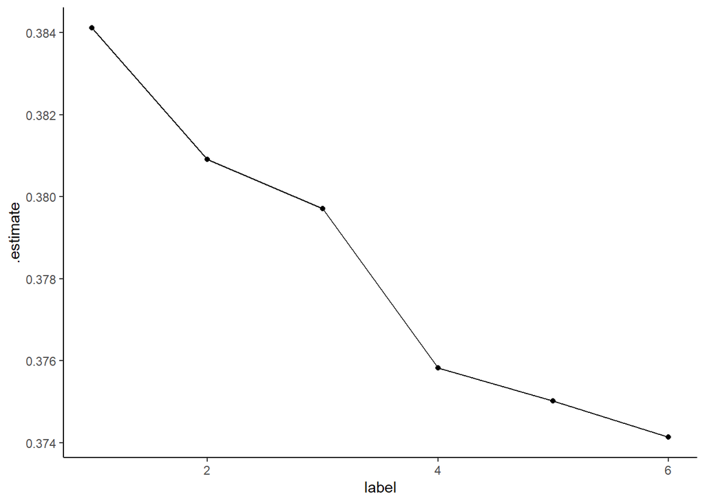

```r
labels <- data_rf_OOB_output %>%
    select(label)
accuracys <- data_rf_OOB_output %>%
    group_by(label) %>%
    accuracy(truth = class,estimate= .pred_class)

ggplot(accuracys,aes(x= label,y=.estimate)) +
  geom_point() +
  geom_line() +
  theme_classic()
```

Considering the bias-variance tradeoff, although `mtry` = 1 leads to very high variance in the decisions among the trees, we know that in the end, when counting the majority votes from all trees in the forest, this model still wins as the one whose majority votes are closest to the truth. This may be due to the fact that `data_fit_mtry1` was able to include splits on “weaker” variables that normally would not “win” in any splits. Thus, `data_fit_mtry1` has more chance to explore the globally best combination of splits, rather than locally best ones that prioritize strong variables or variables that are more correlated with the previously chosen one.

However, there is another tuning parameter we should consider - `min_n`, the minimum number of cases in a node to consider splitting. Since `data_fit_mtry2`’s accuracy is very close to that of `data_fit_mtry1`, we will tune for the best `min_n` on both of these values of `mtry`. It is possible that with a different value of `min_n`, `mtry` = 2 is actually the best one.

#### Tuning for the best min_n

```r
# Model Specification
mtry1_spec <- rand_forest() %>%
  set_engine(engine = 'ranger') %>%
  set_args(mtry = 1, # size of random subset of variables
           trees = 1000, # Number of trees
           min_n = NULL, # tuning parameter is min_n; tuning spec
           probability = FALSE, # FALSE: get hard predictions (not needed for regression)
           importance = 'impurity') %>% # we'll come back to this at the end
  set_mode('classification')

mtry2_spec <- rand_forest() %>%
  set_engine(engine = 'ranger') %>%
  set_args(mtry = 2, # size of random subset of variables
           trees = 1000, # Number of trees
           min_n = NULL, # tuning parameter is min_n; tuning spec
           probability = FALSE, # FALSE: get hard predictions (not needed for regression)
           importance = 'impurity') %>% # we'll come back to this at the end
  set_mode('classification')

# min_n values
min_ns <- seq(5, 100, 5) # 20 values of min_n, from 5 to 100 with step of 5

# Custom function to get OOB result of a random forest model with custom tuning min_n
OOB_output <- function(model_spec, min_ns) {
  mtry_OOB_output <- bind_rows()
  for (min_n in min_ns) {
    # Workflow (Recipe + Model)
    main_wf <- workflow() %>%
      add_model(model_spec %>% set_args(min_n = min_n)) %>%
      add_recipe(data_rec)

    set.seed(253)
    fit_model <- fit(main_wf, data = music_clean)
    mtry_OOB_output <- bind_rows(mtry_OOB_output,
                                 rf_OOB_output(fit_model, min_n, music_clean %>% pull(genre)))
  }
  return (mtry_OOB_output %>%
            group_by(label) %>%
            accuracy(truth = class, estimate = .pred_class))
}

# Result
mtry1_result <- OOB_output(mtry1_spec, min_ns)
mtry2_result <- OOB_output(mtry2_spec, min_ns)
```

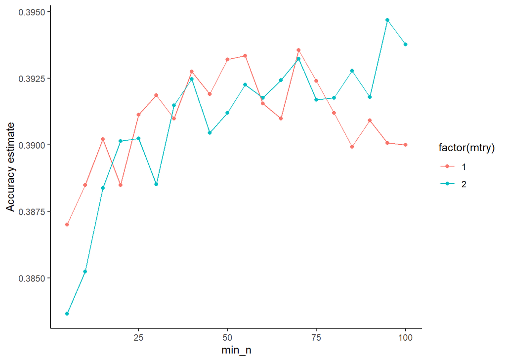

```r
# Bind mtry column
mtry1_result$mtry <- rep_len(1, length(min_ns))
mtry2_result$mtry <- rep_len(2, length(min_ns))

accuracys <- bind_rows(mtry1_result, mtry2_result)

# Visualize how the accuracies of mtry1 and mtry2 change across different min_n's
ggplot(accuracys,aes(x=label, y=.estimate, group=mtry, color=factor(mtry))) +
  geom_point() +
  geom_line() +
  xlab("min_n") + ylab("Accuracy estimate") +
  theme_classic()
```

```r
# Show the random forest model with the best overall accuracy
accuracys %>% slice_max(.estimate)
```

```
## # A tibble: 1 × 5
##   label .metric  .estimator .estimate  mtry
##   <dbl> <chr>    <chr>          <dbl> <dbl>
## 1    95 accuracy multiclass     0.395     2
```

Therefore, we will move forward to examining variable importance with the best random forest model we have concluded.

#### Variable Importance

```r
# Finalize the best random forest model
best_rf_wf <- workflow() %>%
  add_model(mtry2_spec %>% set_args(min_n = 70)) %>% # choose the best mtry and the best min_n
  add_recipe(data_rec)

best_rf_fit <- fit(best_rf_wf, data = music_clean)
```

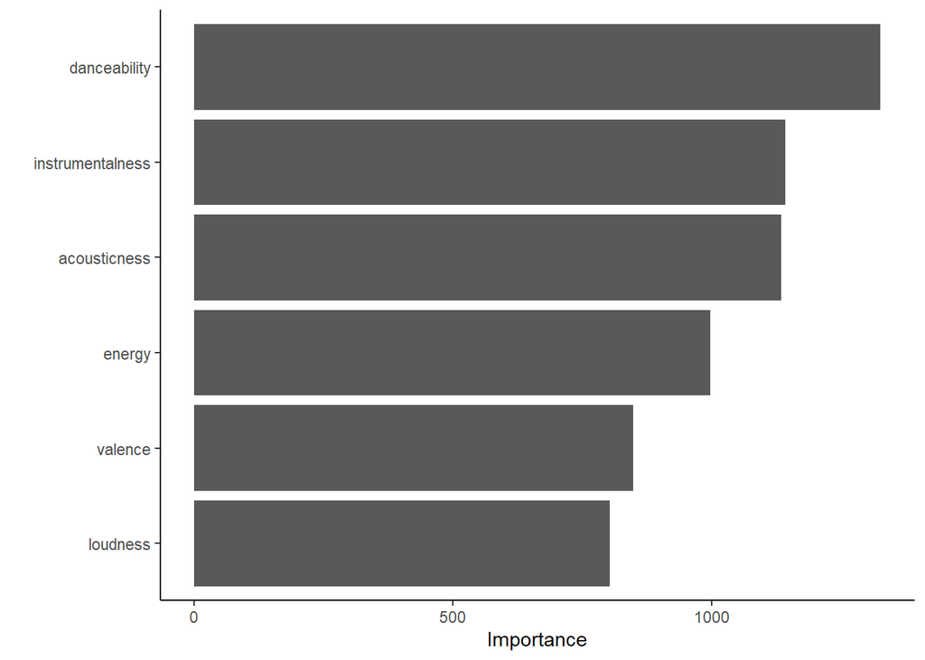

```r
# Impurity approach
impurity_output <- best_rf_fit %>%
    extract_fit_engine()

impurity_output %>%
    vip(num_features = 30) + theme_classic() #based on impurity
```

```r
impurity_output %>% vip::vi() %>% head()
```

```
## # A tibble: 6 × 2
##   Variable         Importance
##   <chr>                 <dbl>
## 1 danceability          1326.
## 2 instrumentalness      1142.
## 3 acousticness          1134.
## 4 energy                 997.
## 5 valence                848.
## 6 loudness               803.
```

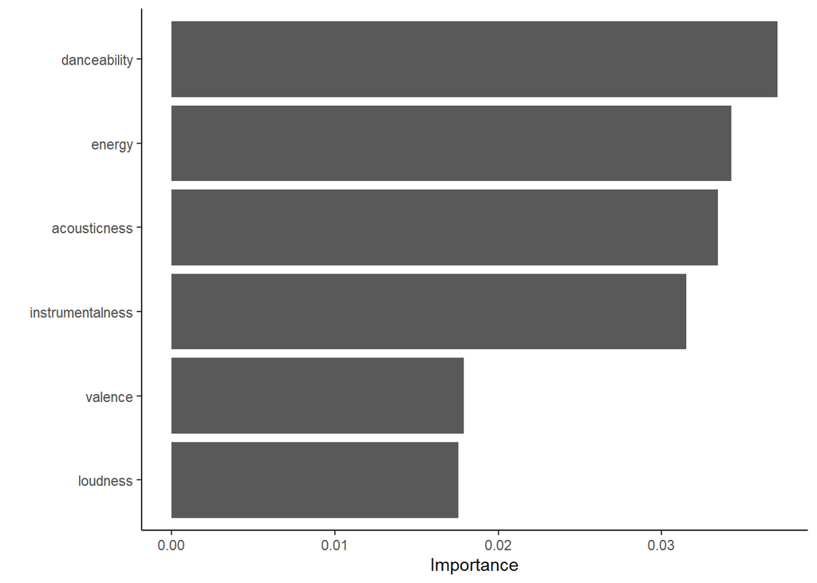

```r
# Permutation approach
permutation_output <- best_rf_fit %>%
  update_model(rf_spec %>% set_args(importance = "permutation")) %>% #based on permutation
  fit(data = music_clean) %>%
    extract_fit_engine()

permutation_output %>%
    vip(num_features = 30) + theme_classic()
```

```r
permutation_output %>% vip::vi() %>% head()
```

```
## # A tibble: 6 × 2
##   Variable         Importance
##   <chr>                 <dbl>
## 1 danceability         0.0371
## 2 energy               0.0343
## 3 acousticness         0.0335
## 4 instrumentalness     0.0315
## 5 valence              0.0179
## 6 loudness             0.0176
```

Both measurements agree on the the rank of `danceability` (most important), `valence` (5th rank), and `loudness` (6th, last rank) but disagree on the rank of `energy`, `instrumentalness` and `acousticness`. Impurity ranks `energy` lower than `instrumentalness` and acousticness`, while permutation ranks`energy` higher than both.

However, we know that the impurity measure tends to favor predictors with a lot of unique values, because with many unique values, there are many more possible splits, thus making it easier to find an optimal split that makes a big improvement in purity. Therefore, we believe that the result from the permutation approach is more reliable.

To find out whether this is actually the case, we will take a look at the number of unique values of these predictors:

```r
# Count the number of unique values of each predictor
music_clean %>% select(instrumentalness, acousticness, energy) %>%
  sapply(function (x) n_distinct(x))
```

```
## instrumentalness     acousticness           energy
##             4939             3786             1348
```

As it turns out, impurity may have actually favored predictors with more unique values - `instrumentalness` has 3.66 times more unique values than `energy`, while `acousticness` has 2.81 more unique values than `energy`. Therefore, the variable importance rankings of permutation is more likely to be accurate.

Next, we will use an alternative model type to answer our research questions.

### K-nearest Neighbors

#### Fitting Models

To find the best K - the number of neighbors, we will start with a tuning grid of 50 values of K from 1 to 500. We will also use cross validation to avoid overfitting and get the true test error.

```r
# CV Folds
data_cv10 <- vfold_cv(music_clean, v = 10)

# Model Specification
knn_spec <-
  nearest_neighbor() %>% # new type of model!
  set_args(neighbors = tune()) %>% # tuning parameter is neighbor; tuning spec
  set_engine(engine = 'kknn') %>% # new engine
  set_mode('classification')

# Recipe with standardization (!)
data_rec <- recipe( genre ~ danceability+loudness+acousticness+instrumentalness+valence+energy , data = music_clean) %>%
    step_nzv(all_predictors())# removes variables with the same value

# Workflow (Recipe + Model)
knn_wf <- workflow() %>%
  add_model(knn_spec) %>%
  add_recipe(data_rec)

# Tune model trying a variety of values for neighbors (using 10-fold CV)
penalty_grid <- grid_regular(
  neighbors(range = c(1, 500)), #  min and max of values for neighbors
  levels = 50) # number of neighbors values

knn_fit_cv <- tune_grid(knn_wf, # workflow
              resamples = data_cv10, #CV folds
              grid = penalty_grid, # grid specified above
              metrics = metric_set(accuracy))
```

#### Evaluation

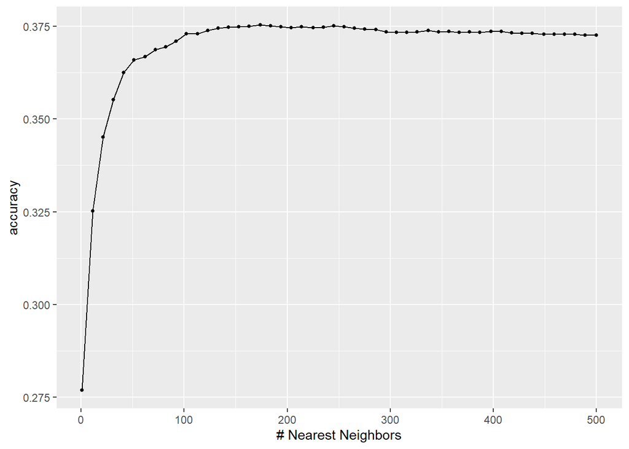

```r
knn_fit_cv %>% autoplot()
```

```r
knn_fit_cv %>% show_best(metric = 'accuracy') # Show evaluation metrics for different values of neighbors, ordered
```

```
## # A tibble: 5 × 7
##   neighbors .metric  .estimator  mean     n std_err .config
##       <int> <chr>    <chr>      <dbl> <int>   <dbl> <chr>
## 1       174 accuracy multiclass 0.375    10 0.00402 Preprocessor1_Model18
## 2       184 accuracy multiclass 0.375    10 0.00418 Preprocessor1_Model19
## 3       245 accuracy multiclass 0.375    10 0.00456 Preprocessor1_Model25
## 4       163 accuracy multiclass 0.375    10 0.00404 Preprocessor1_Model17
## 5       255 accuracy multiclass 0.375    10 0.00443 Preprocessor1_Model26
```

```r
knn_fit_cv %>%
  select_by_one_std_err(metric = 'accuracy', desc(neighbors))  # Choose neighbors value that leads to the highest neighbors within 1 se of the lowest CV MAE
```

```
## # A tibble: 1 × 9
##   neighbors .metric  .estimator  mean     n std_err .config         .best .bound
##       <int> <chr>    <chr>      <dbl> <int>   <dbl> <chr>           <dbl>  <dbl>
## 1       500 accuracy multiclass 0.373    10 0.00419 Preprocessor1_… 0.375  0.371
```

#### Variable Importance

```r
# Variable importance
orig_accuracy <- 0.3753346

spec_wo_var <- nearest_neighbor(neighbors=174) %>% # new type of model!
  set_engine(engine = 'kknn') %>% # new engine
  set_mode('classification')

calculate_var_importance <- function(var) {
  new_data <- music_clean %>% select(-var)
  rec_wo_var <- recipe(genre ~ ., data = new_data)

  # Workflow (Recipe + Model)
  wf_wo_var <- workflow() %>%
    add_model(spec_wo_var) %>%
    add_recipe(rec_wo_var)

  knn_mod_wo_var <- fit_resamples(wf_wo_var,
    resamples = data_cv10,
    metrics = metric_set(yardstick::accuracy))

  accuracy_wo_var <- knn_mod_wo_var %>% collect_metrics()
  return (c(var, orig_accuracy - accuracy_wo_var %>% pull(mean)))
}

result <- data.frame(matrix(ncol=2,nrow=6, dimnames=list(NULL, c("variable", "difference"))))

result[1,] <- calculate_var_importance('danceability')
result[2,] <- calculate_var_importance('energy')
result[3,] <- calculate_var_importance('instrumentalness')
result[4,] <- calculate_var_importance('acousticness')
result[5,] <- calculate_var_importance('valence')
result[6,] <- calculate_var_importance('loudness')

result %>% arrange(difference)
```

```
##           variable          difference
## 1         loudness 0.00613279847614195
## 2     acousticness  0.0115256453900847
## 3          valence  0.0128294549358957
## 4           energy  0.0154729062784314
## 5 instrumentalness  0.0201604602286359
## 6     danceability  0.0236851365398292
```

## Results

```r
accuracys %>% slice_max(.estimate)
```

```
## # A tibble: 1 × 5
##   label .metric  .estimator .estimate  mtry
##   <dbl> <chr>    <chr>          <dbl> <dbl>
## 1    95 accuracy multiclass     0.395     2
```

```r
permutation_output %>% vip::vi() %>% head()
```

```
## # A tibble: 6 × 2
##   Variable         Importance
##   <chr>                 <dbl>
## 1 danceability         0.0371
## 2 energy               0.0343
## 3 acousticness         0.0335
## 4 instrumentalness     0.0315
## 5 valence              0.0179
## 6 loudness             0.0176
```

## Conclusions

#### Variable Importance Interpretation

```r
# Average values of features
music_clean %>%
  group_by(genre) %>%
  summarize(avg_danceability=mean(danceability), avg_energy=mean(energy), avg_instrumentalness=mean(instrumentalness),avg_acousticness=mean(acousticness), avg_valence=mean(valence), avg_loudness=mean(loudness))
```

```
## # A tibble: 7 × 7
##   genre   avg_danceability avg_energy avg_instrumental…¹ avg_a…² avg_v…³ avg_l…⁴
##   <fct>              <dbl>      <dbl>              <dbl>   <dbl>   <dbl>   <dbl>
## 1 blues              0.481      0.582             0.0945   0.365   0.546   0.664
## 2 country            0.540      0.466             0.0183   0.457   0.533   0.634
## 3 hip hop            0.729      0.703             0.0154   0.144   0.604   0.727
## 4 jazz               0.516      0.463             0.234    0.503   0.467   0.607
## 5 pop                0.525      0.601             0.0461   0.305   0.532   0.684
## 6 reggae             0.706      0.590             0.0502   0.180   0.706   0.682
## 7 rock               0.464      0.701             0.0928   0.197   0.458   0.708
## # … with abbreviated variable names ¹avg_instrumentalness, ²avg_acousticness,
## #   ³avg_valence, ⁴avg_loudness
```

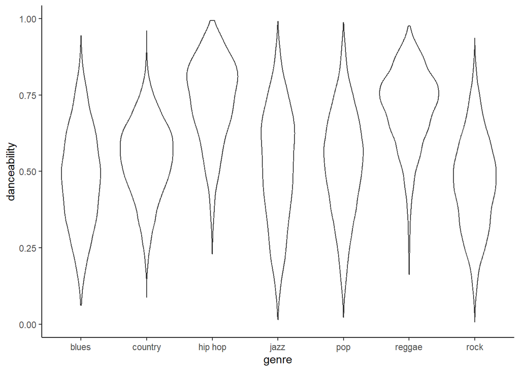

```r
# Violin plots of the predictors, in the order of permutation measurement
ggplot(music_clean, aes(x = genre, y = danceability)) +
    geom_violin() + theme_classic()
```

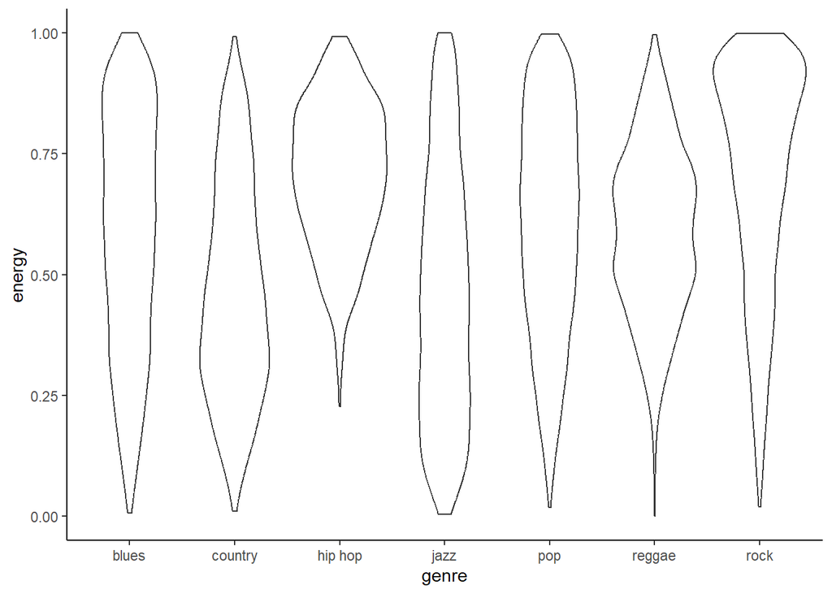

```r
ggplot(music_clean, aes(x = genre, y = energy)) +
    geom_violin() + theme_classic()
```

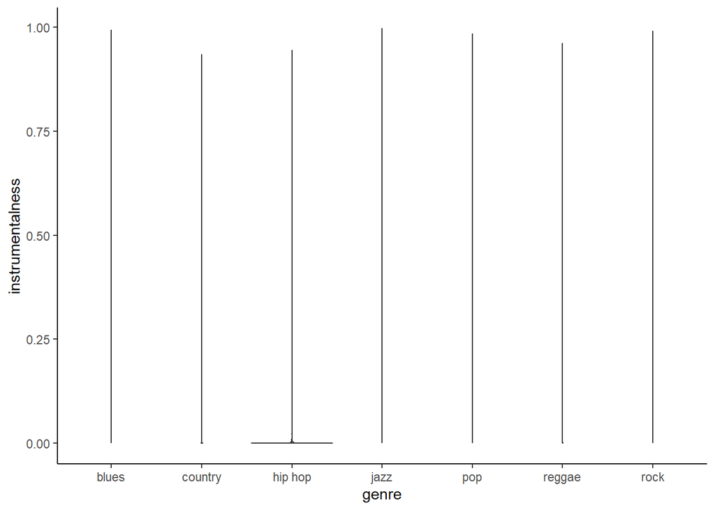

```r
ggplot(music_clean, aes(x = genre, y = instrumentalness)) +
    geom_violin() + theme_classic()
```

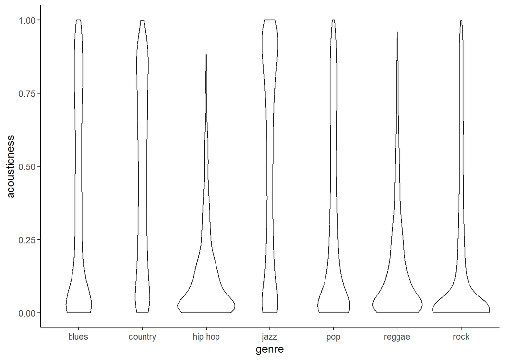

```r
ggplot(music_clean, aes(x = genre, y = acousticness)) +
    geom_violin() + theme_classic()
```

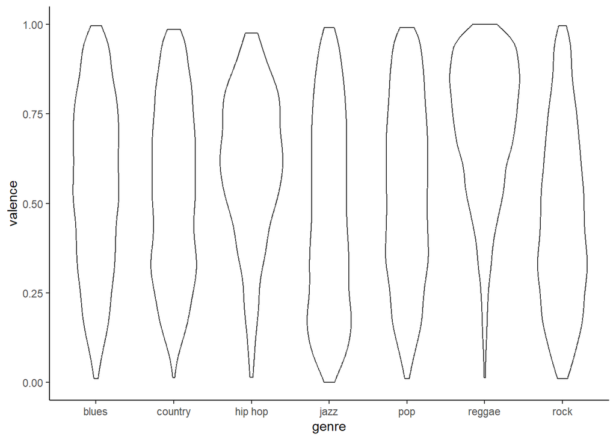

```r
ggplot(music_clean, aes(x = genre, y = valence)) +
    geom_violin() + theme_classic()
```

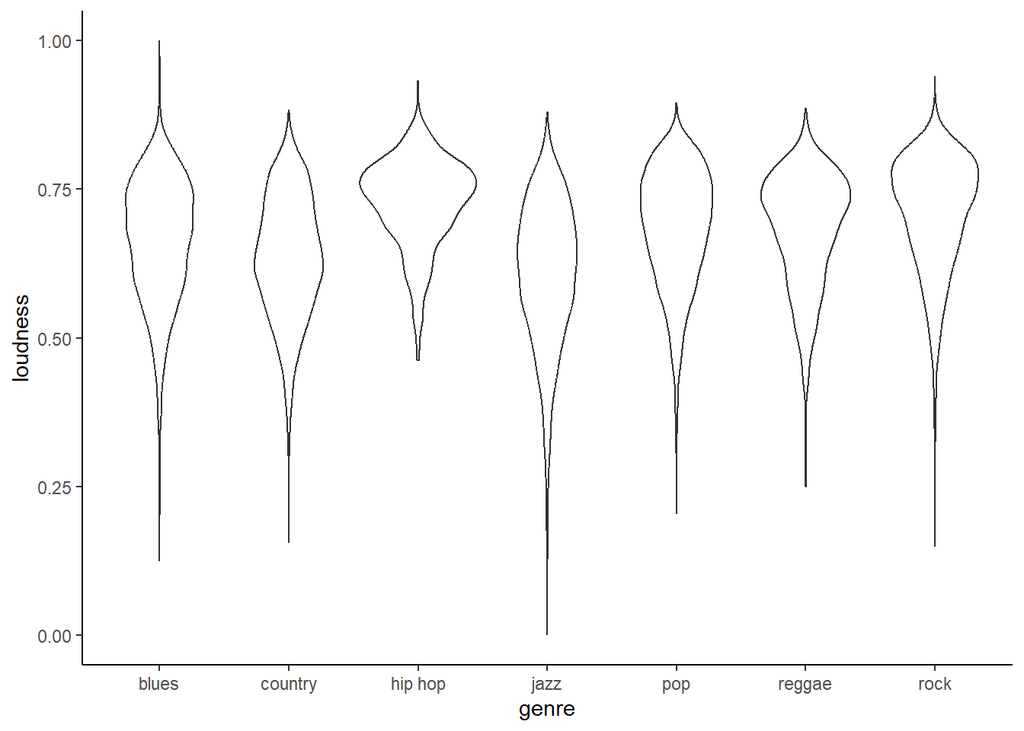

```r
ggplot(music_clean, aes(x = genre, y = loudness)) +
    geom_violin() + theme_classic()
```

From the average scores above, there are several observations: - Hip hop and reggae are much more `danceable` than other genres. This makes sense, because these 2 genres are commonly known as “dance music”. - Hip hop and rock score quite noticeably higher on `energy`. than other genres. - Jazz has the highest `instrumentalness` (~less vocal), but the difference to the second most instrumental genre is only 0.23357732 - 0.09453841 = 0.13903891. After jazz, blues and rock are also twice or more as instrumental as the remaining genres. - Hip hop, reggae, and rock are generally much less `acoustic`. - Again, hip hop and reggae score the highest on `valence`, although not as evident as with danceability. - `Loudness` does not differ much among the genres.

Both the average feature values and the violin plots are generally in agreement with our final ranking of variable importance.

#### Confusion Matrix

```r
# Confusion Matrix
rf_OOB_output(best_rf_fit, "mtry = 2, min_n = 70", music_clean %>% pull(genre)) %>%
  conf_mat(truth = class, estimate = .pred_class)
```

```
##           Truth
## Prediction blues country hip hop jazz  pop reggae rock
##    blues    1169     458      13  363  697     96  559
##    country  1063    2743      50  869 1546    293  512
##    hip hop     3      15     172   19   80     58   14
##    jazz      460     283      22 1484  463    127  278
##    pop      1217    1612     430  652 3174    756 1313
##    reggae    181     205     201  189  426   1105  101
##    rock      511     129      16  269  656     63 1257
```

Looking at the confusion matrix, we can see that except for blues, hip hop and rock, our best model predicted the correct genre more times than each of the incorrect genres. Looking at actual numbers, interpretations are difficult to make given that the proportions for each genre were not equal and varied wildly. However, here, we will list out the genres that our model misidentified the most for each of the true observed genres:

- blues: commonly misidentified as **pop** and country.
- country: commonly misidentified as pop
- hip hop: commonly misidentified as **pop**, **reggae**
- jazz: commonly misidentified as country, pop
- pop: commonly misidentified as country
- reggae: commonly misidentified as pop, country
- rock: commonly misidentified as **pop**

Note that the bolded genres are the ones that get predicted even more times than the true genre.

One interesting observation we can make is that for when the model predicted reggae, it turned out to be hip hop more times than jazz and blues, despite hip hop having the lowest proportion of songs (904 songs vs jazz’s 3845 songs and blues’ 4604 songs) meaning it overpredicted reggae for hip hop in comparison to other false genres. This makes sense given how hip hop and reggae both has generally high danceability, high valance, and low acousticness.

## Unsupervised Learning

### Data exploration

First, let’s explore the distribution of topics in our dataset:

```r
topic_count <- music %>% group_by(topic) %>%
  summarise(n = n()) %>% mutate(freq=n/sum(n)) %>% arrange(-freq)
topic_count
```

```
## # A tibble: 8 × 3
##   topic          n   freq
##   <chr>      <int>  <dbl>
## 1 sadness     6096 0.215
## 2 violence    5710 0.201
## 3 world/life  5420 0.191
## 4 obscene     4882 0.172
## 5 music       2303 0.0812
## 6 night/time  1825 0.0643
## 7 romantic    1524 0.0537
## 8 feelings     612 0.0216
```

There are 8 topics: sadness, violence, world/life, obscene, music, night/time, romantic, and feelings. The former 4 topics in the same order are the more prevalent ones. Since we want to relate these topics with the 7 genres, we will use only the musical features most important in classifying genres to do clustering, which, according to the result of research question #2, are: danceability, energy, instrumentalness, and acousticness. Reducing these number of variables will help avoid overfitting, and reduce computational resource while maintaining the predictive power. To perform clustering, we choose K-means over hierarchical clustering, because we want there to be 7 clusters corresponding to the 7 genres. Another reason is that we do not need to interpret the distances between tracks, because there are too many of them, and because eventually, we are not interested in how similar the tracks are in a cluster (except when tuning for the best model).

### Method

```r
music_clean_3 <- music

# Select only the most important musical features in identifying tracks' genres
# Musical feature variables in the original dataset are already standardized, so we do not need to do that here.
music_clean_3_sub <- music_clean_3 %>% select(danceability, acousticness, instrumentalness, energy)
```

```r
# Set the seed before performing clustering to get repeatable results
set.seed(253)

# Group the tracks into 7 clusters (based on cluster centroids)
kclust_k7 <- kmeans(music_clean_3_sub, centers = 7)

# Assign clusters to tracks
music_clean_3 <- music_clean_3 %>%
    mutate(kclust_7 = factor(kclust_k7$cluster))
```

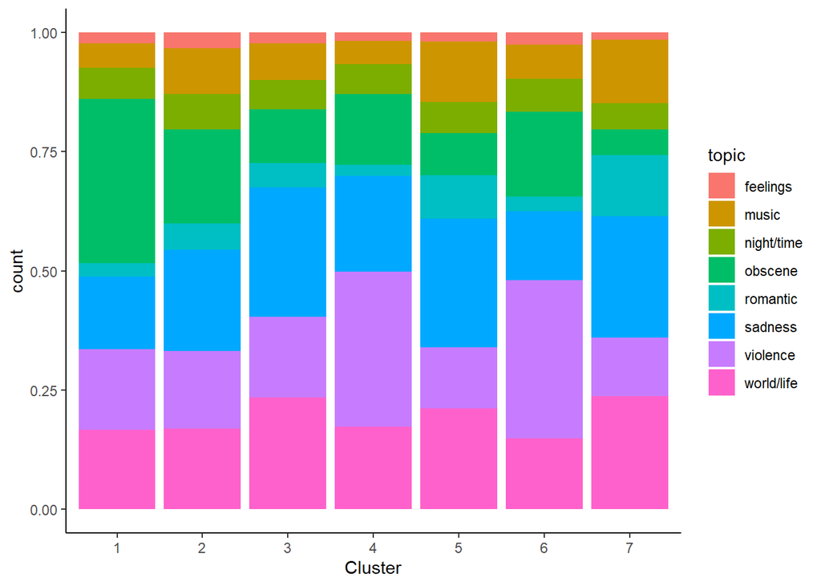

```r
# Visualize the cluster assignments, labeled by topic
ggplot(music_clean_3, aes(x = kclust_7, fill = topic)) +
    geom_bar(position = "fill") +
    labs(x = "Cluster") +
    theme_classic()
```

As seen in the 1st graph, in cluster 4 and cluster 6, the most prevalent topic is “violence”. We will check to see if these 2 clusters account for most of the tracks whose observed topic is “violence”.

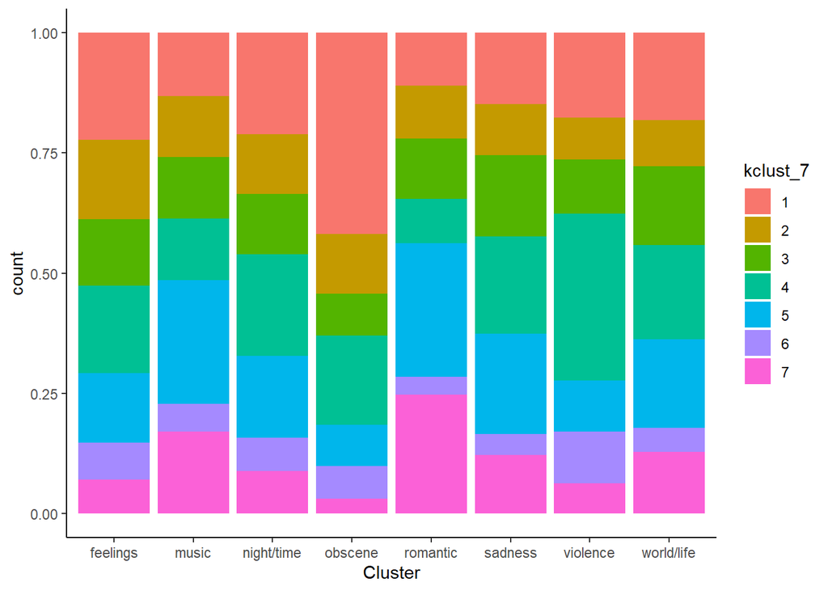

```r
# Visualize the 8 topics, labeled by cluster assignment
ggplot(music_clean_3, aes(x = topic, fill = kclust_7)) +
    geom_bar(position = "fill") +
    labs(x = "Cluster") +
    theme_classic()
```

Interestingly, only cluster 4 makes up more than 25% of “violence” tracks. The second most common cluster is cluster 1, but compared to other topics, “violence” is not the most, even the second most, prevalent topic for cluster 1. While cluster 6 makes up only a small part of every topic, its most common topic is clearly “violence”.

Next, we look at the genres of these clusters, with more attention to cluster 4 and 6.

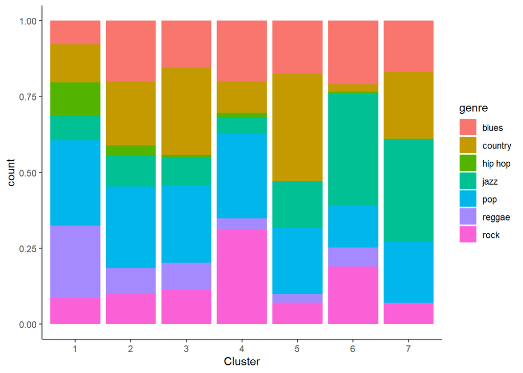

```r
# Visualize cluster assignments, labeled by genre
ggplot(music_clean_3, aes(x = kclust_7, fill = genre)) +
    geom_bar(position = "fill") +
    labs(x = "Cluster") +
    theme_classic()
```

In cluster 4, we see 3 genres make up the most of it: rock, pop, and blues in the order of their proportion. In cluster 6, we also see 3 most common genres: jazz, blues, and rock. So, rock and blues are the 2 overlapping common genre of these two clusters.

Let’s also look at the a visualization of cluster composition of the 7 genres to gain more insights:

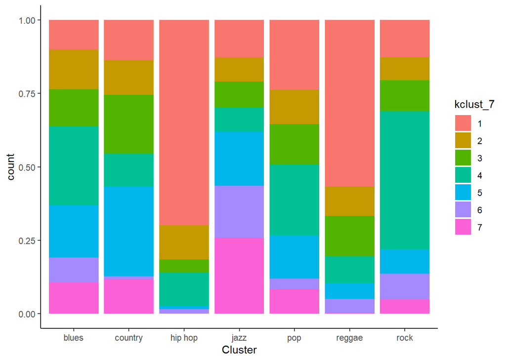

```r
ggplot(music_clean_3, aes(x = genre, fill = kclust_7)) +
    geom_bar(position = "fill") +
    labs(x = "Cluster") +
    theme_classic()
```

Interestingly, rock has up to about 50% of its tracks belonging to cluster 4 - the “most violent cluster”. If we combine cluster 4 and 6 in each genre, we can see that blues, pop, and jazz in order also has a large number of tracks from cluster 4 and 6 (compared to country, hip hop, and reggae), but not as many as rock. At this point, we can tentatively conclude that rock, blues, pop, and jazz in order are the genres that tend to be violent the most.

However, this result may happen by chance, because in K-means, the algorithms randomly assign 7 clusters at the beginning, which means the final cluster assignments may have been different if we use a different seed. Therefore, before we make the final conclusion, we will run the algorithm with different seeds to have different random initializations. The best initialization will have the smallest within-cluster sum of squares.

### Choosing the best random initialization

Because we have a very large dataset, we will test with 100 different seeds to make sure we will get the best seeds within the test range.

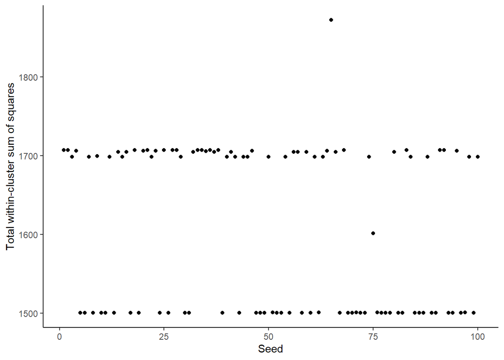

```r
# Data-specific function to cluster and calculate total within-cluster sum of squares
music_cluster_ss <- function(seed){
  set.seed(seed)

  # Perform clustering
  kclust <- kmeans(music_clean_3_sub, centers = 7)

  # Return the total within-cluster sum of squares
  return(kclust$tot.withinss)
}

results <- tibble(
    k = 1:100,
    total_wc_ss = purrr::map_dbl(1:100, music_cluster_ss)
)

results %>%
    ggplot(aes(x = k, y = total_wc_ss)) +
    geom_point() +
    labs(x = "Seed",y = 'Total within-cluster sum of squares') +
    theme_classic()
```

```r
results %>% slice_min(total_wc_ss)
```

```
## # A tibble: 7 × 2
##       k total_wc_ss
##   <int>       <dbl>
## 1    39       1500.
## 2    43       1500.
## 3    55       1500.
## 4    67       1500.
## 5    72       1500.
## 6    86       1500.
## 7    93       1500.
```

As it turns out, initializations with seed = 39, 43, 55, 67, 72, 86, 93 are the best. Their total within-cluster sum of squares are the same, at 1500.301.

### Interpretation with the best initializations

We will now test our tentative interpretations above (with seed = 253) with 3 of the best seeds. Ideally, whatever the seed is, we want to have 2 clusters whose most common topic is violence, and within these 2 clusters, the most prevalent genres are rock, blues, pop, and jazz.

```r
k_means <- function() {
  kclust_k7 <- kmeans(music_clean_3_sub, centers = 7)

  music_clean_3 <- music_clean_3 %>%
    mutate(kclust_7 = factor(kclust_k7$cluster))

  topic <- ggplot(music_clean_3, aes(x = kclust_7, fill = topic)) +
    geom_bar(position = "fill") +
    labs(x = "Cluster") +
    theme_classic()

  show(topic)

  genre <- ggplot(music_clean_3, aes(x = kclust_7, fill = genre)) +
    geom_bar(position = "fill") +
    labs(x = "Cluster") +
    theme_classic()

  show(genre)
}
```

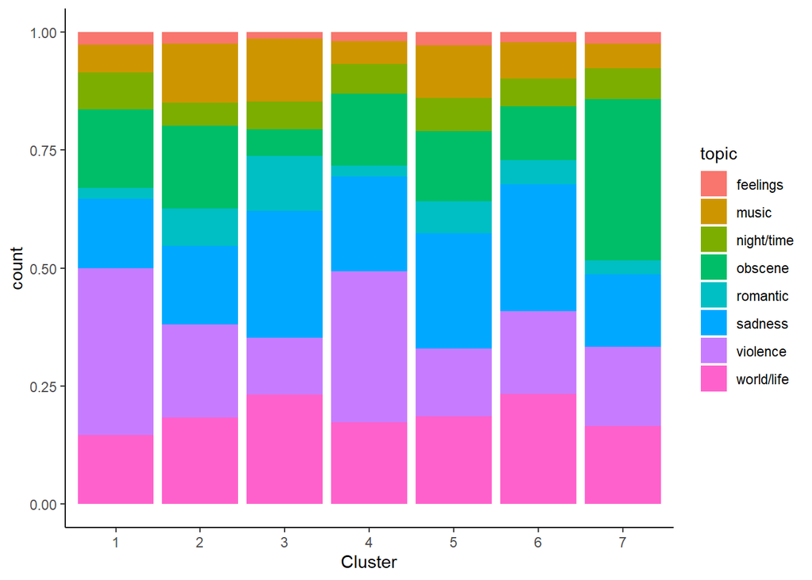

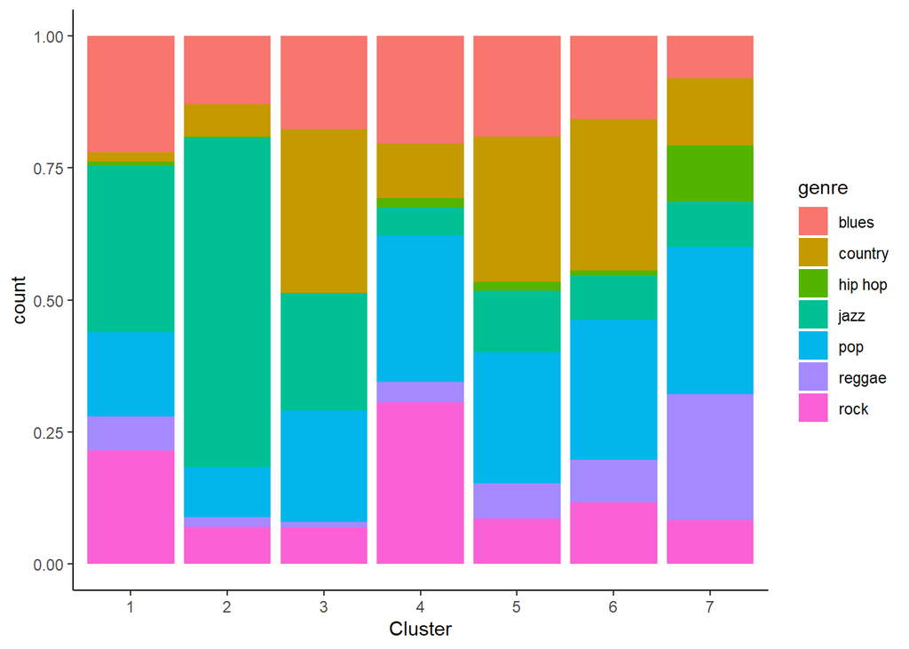

```r
set.seed(39)
k_means()
```

With seed = 39, K-means gives us all the same conclusions as with seed = 253, although the exact numbers may be slightly different. Cluster 1 and 4 are the “most violent clusters”. In cluster 1, jazz, blues, and rock are the most common genres (same as cluster 6 when seed = 253). In cluster 4, rock, pop, and blues are the most common genres (same as cluster 4 when seed = 253). The order of prevalence of these genres within each of these two cluster remains the same.

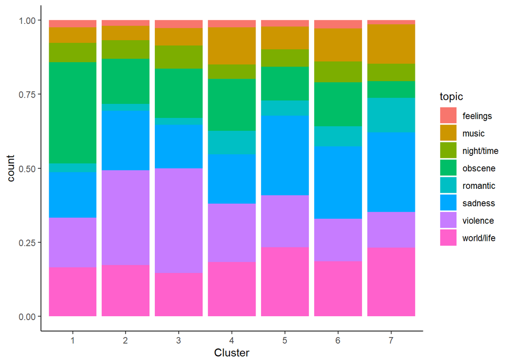

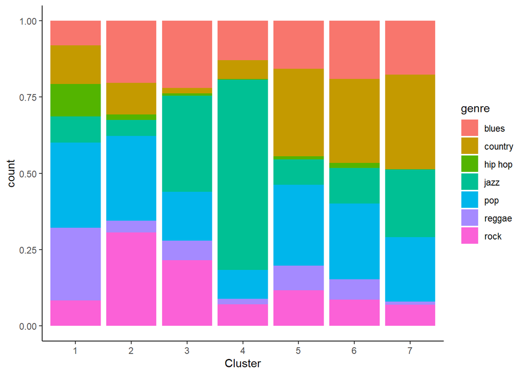

```r
set.seed(43)
k_means()
```

With seed = 43, the conclusions remain the same. Cluster 2 here corresponds to cluster 4 when seed = 253. Cluster 3 here corresponds to cluster 6 when seed = 253.

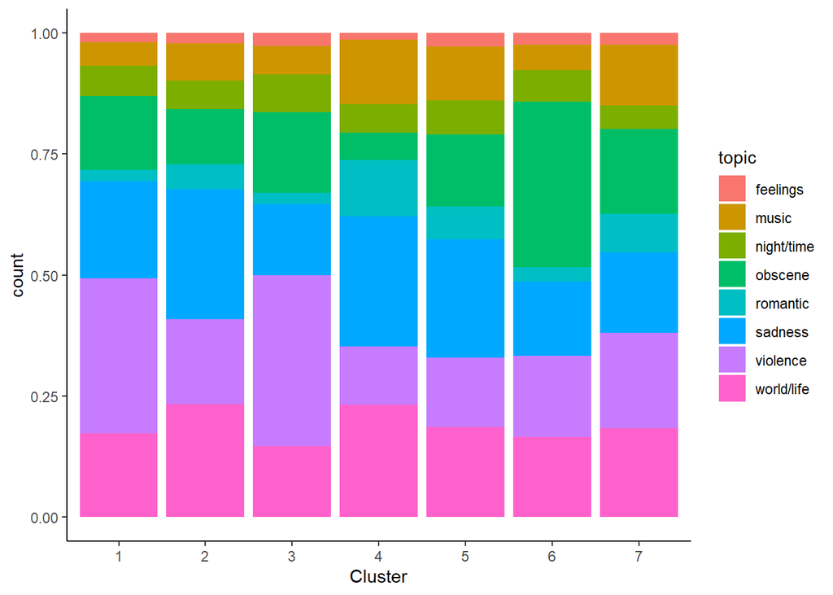

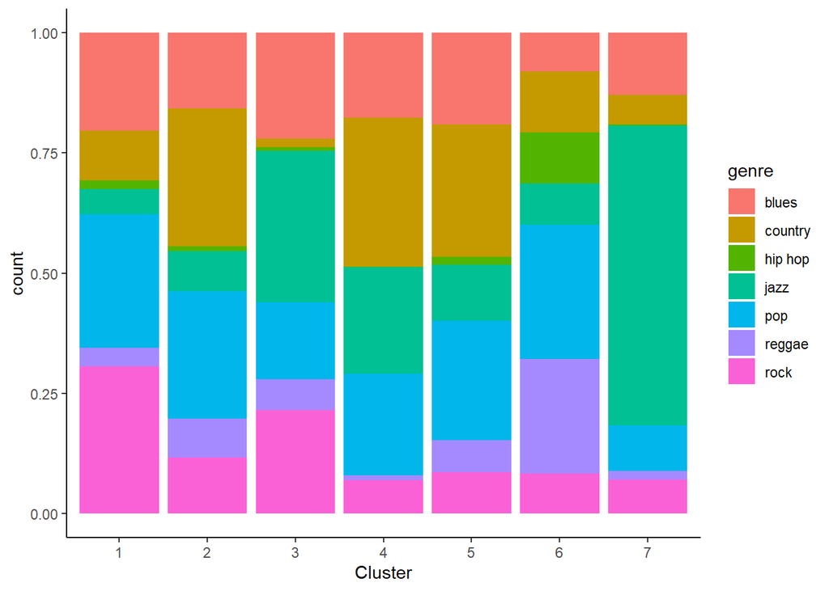

```r
set.seed(67)
k_means()
```

Again, the conclusions remain the same with seed = 67. Cluster 1 here corresponds to cluster 4 when seed = 253. Cluster 3 here corresponds to cluster 6 when seed = 253.